# Community Engagement

# 2021-present: R Workshop Instructor

## *University of Toronto, Conferences, R Users Meetup*

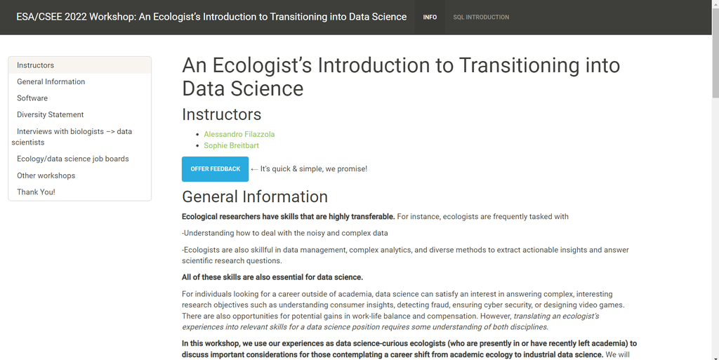

**I love to code. I also love to help others realize that it’s not the for loops that make their blood pressure rise, but the environments in which they were taught for loops.** That a supportive environment can make *all the difference* when it comes to learning these incredibly powerful, multi-disciplinary skills that offer immense value to practically every field. I am grateful to have been given the chance to undergo instructor training through [The Carpentries](https://carpentries.org/), an organization that teaches “foundational coding and data science skills to researchers worldwide”, and team up with some incredible colleagues to develop coding workshops for researchers at UofT (e.g., as a [UofT Coders](https://uoftcoders.github.io/) exec) and beyond.

# 2018-present: Contributing Writer, “Life in the City”

## *A blog about urban evolution*

[figure not shown]

**In an effort to hone my written science communication skills**, I contribute articles to [Life in the City](https://urbanevolution-litc.com/author/sophie-breitbart/), a blog about urban evolution. I’ve searched for the boundary between urban/nonurban (hint: [let me know if you find it](https://urbanevolution-litc.com/2019/07/30/urbanization-beyond-where-the-sidewalk-ends/)), explored a relatively uncharted biome associated with urbanization ([the “indoor biome”](https://urbanevolution-litc.com/2019/09/03/what-is-the-indoor-biome/)), [compiled auditory learning resources on urban evolution](https://urbanevolution-litc.com/2018/12/14/audible-resources-for-urban-evolution/), and more. I enjoy blogging as **a way to challenge myself by breaking down a complex idea into fundamental parts.** I also see it as **an opportunity to inspire the public by using accessible language** so that they, too, can appreciate the amazing world of urban evolution.

# 2020-2022: Coordinator, CAGIS Toronto

## *Canadian Association for Girls in Science*

[figure not shown]

From 2020-2022, I was a coordinator for the Toronto chapter of [CAGIS](https://girlsinscience.ca/what-is-cagis/), a club whose **mission is to encourage young girls and gender non-conforming youth (age 7-16) to explore the STEM fields with hands-on activities**. Since I began volunteering with CAGIS in 2019, I’ve assisted these budding scientists as **they’ve built solar-powered cars, searched for fungi in High Park, pondered the logistics of space travel, and constructed mini greenhouses** for germinating household seeds and beans. When I became a chapter coordinator in 2020, my role expanded to include organizing virtual events with community partners in academia, industry, and government.